# Network Analysis in Python

## Laila A. Wahedi, PhD

### Massive Data Institute Postdoctoral Fellow McCourt School of Public Policy

### Follow along:

- Slides: http://Wahedi.us, Tutorial
- Interactive Notebook: https://notebooks.azure.com/Laila/projects/mdi-network-analysis-workshop

# Follow Along

1. Go to https://notebooks.azure.com/Laila/projects/mdi-network-analysis-workshop
2. Clone the directory

[figure not shown]

# Follow Along

1. Sign in with any Microsoft Account (Hotmail, Outlook, Azure, etc.)
   - Create a folder to put it in, mark as private or public

[figure not shown]

# Follow Along

1. Open a notebook
   - Open *this* notebook to have the code to play with
   - Open a blank notebook to follow along and try on your own.

[figure not shown]

# Do you get this error?

### HTTP Error 400. The size of the request headers is too long

# Clear your cookies then refresh the browser.

# Your Environment

- Jupyter Notebook Hosted in Azure
- Want to install it at home?
  - Install the Anaconda distribution of Python https://www.anaconda.com/download/
  - Install Jupyter Notebooks http://jupyter.org/install

# Your Environment

- ctrl/apple+ enter runs a cell

[figure not shown]

# Your Environment

- Persistent memory
  - If you run a cell, results remain as long as the kernel

### ORDER MATTERS!

```python
foo = 'some variable content'
```

```python
print(foo)
```

```
some variable content
```

# Your Environment: Saving

- If your kernel dies, data are gone.
- Not R or Stata, you can't save your whole environment
- Data in memory more than spreadsheets
- Think carefully about what you want to save and how.

# Easy Saving: Pickle

- dump to save the data to hard drive (out of memory)
- Contents of the command:
  - variable to save,
  - File to dump the variable into:
    - open(  
      "name of file in quotes",  
      "wb") "Write Binary"
- Note: double and single quotes both work

```python
mydata = [1,2,3,4,5,6,7,8,9,10]
pickle.dump(mydata, open('mydata.p','wb'))
mydata = pickle.load(open("mydata.p","rb"))
```

# Get your environment ready

- We'll cover the basics later, for now start installing and loading packages by running the following code:

```python
import networkx as nx
import pandas as pd
import numpy as np
import pickle
import itertools
import matplotlib.pyplot as plt
import pysal as ps
import statsmodels.api as sm
%matplotlib inline
```

# Last time on Network Analysis in Python...

## Before Constructing a Network...

## What Do We Want From Relational Data?

[figure not shown]

# Types of Analysis:

[figure not shown]

# Types of Analysis:

[figure not shown]

# Types of Analysis:

[figure not shown]

# Types of Analysis:

[figure not shown]

# Types of Analysis:

[figure not shown]

# Types of Analysis:

[figure not shown]

# Types of Analysis:

[figure not shown]

# Types of Analysis:

[figure not shown]

# Types of Analysis:

[figure not shown]

# Today:

### Use some of the tools we from last week, (plus some new ones) to ask network questions about our data

- What is your data?
- What questions are you interested in?

# Asking Network Questions

1. Hypothesize about behavior or a structural constraint
   - Behavior: People make friends with those with similar interests (Homophily)
   - Structural Constraint: People are more likely to interact with others close by
1. How do you expect that behavior to affect the network, or vice versa
   - Homophily should lead to clustering
   - Expect geographic clusters of friends
1. Are there other hypotheses that predict the same observed network? Can you distinguish them?
   - Is clustering centered on attributes or geography? How much is due to which?
1. Is the expected pattern more prevelant in the observed network than a random network?
   - What is the probability that your network could have been generated randomly without your hypothesized dynamic?
   - Regression: Does an individual attribute correlate with an expected pattern?

# Let's Instantiate Some graphs to work with:

### Florentine Marriage Networks

- Families in this graph are connected when there are marriage ties between them

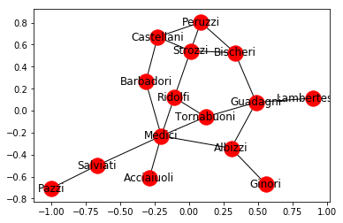

```python
florentine = nx.generators.social.florentine_families_graph()
nx.draw_networkx(florentine)
```

# Let's Instantiate Some graphs to work with:

### Karate Club Graph:

- Interactions between members of a drama-fraught university karate club outside of official club activities.

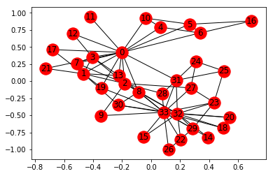

```python
karate = nx.generators.social.karate_club_graph()
nx.draw_networkx(karate)
```

# Karate Club:

- A fight broke out between an administrator and instructor, breaking the club into two organizations.
- Hypothesis: Pre-existing friendships influence which side individuals will pick in a fight
- Alt-Hypothesis: People will side with the person they think is right in a conflict
- Test: Does clustering of friendships predict who will join which new karate club?

# Community Detection: Review

- Divide the network into subgroups using different algorithms
- Girvan Newman Algorithm: Remove ties with highest betweenness, continue until network broken into desired number of communities

[figure not shown]

Image from: https://slideplayer.com/slide/4607021/

# Community Detection: Modularity Maximization

- Find divide that maximizes internal connections, minimizes external connections

[figure not shown]

  Image from https://www.slideshare.net/ErikaFilleLegara/community-detection-with-networkx-59540229

# Community Detection: Modularity Maximization

- Find divide that maximizes internal connections, minimizes external connections

[figure not shown]

Image from https://www.slideshare.net/ErikaFilleLegara/community-detection-with-networkx-59540229

# Modularity Maximization Algorithms

- As graphs get bigger, impossible to try all combinations of divisions to find the best one.
- Different algorithms try to maximize modularity in different ways
  - leidenalg implements package one of the best, works with igraph.
  - python-louvain/ community work with networkx
  - Built-in Networkx algorithm for unweighted undirected networks

```python
modular_communities = nx.algorithms.community.modularity_max.greedy_modularity_communities
greedy_comms = modular_communities(karate)
```

# How did they do?

```python
boundary = nx.algorithms.boundary.edge_boundary
print('quality: ',nx.algorithms.community.quality.performance(karate,greedy_comms),
     'density: ',nx.density(karate))
for i,com in enumerate(greedy_comms):
    n = len(nx.subgraph(karate,com).edges)
    b = [len(list(boundary(karate,com,c))) for c in greedy_comms[:i]+greedy_comms[i+1:]]
    d = nx.density(nx.subgraph(karate,com))
    print('internal edges: ',n, 'external edges: ',sum(b), 'density: ',d)
```

```
quality:  0.714795008912656 density:  0.13903743315508021
internal edges:  34 external edges:  10 density:  0.25
internal edges:  13 external edges:  16 density:  0.3611111111111111
internal edges:  12 external edges:  12 density:  0.42857142857142855
```

# Okay, but we got three and there were two sides to the fight. Let's try Newman Grivan

```python
ng_comms = nx.algorithms.community.centrality.girvan_newman(karate)
for com in itertools.islice(ng_comms,1):
    ng_comms = [c for c in com]
```

# How did Newman Grivan do?

```python
print('quality: ',nx.algorithms.community.quality.performance(karate,ng_comms),
     'density: ',nx.density(karate))
for i,com in enumerate(ng_comms):
    n = len(nx.subgraph(karate,com).edges)
    b = [len(list(boundary(karate,com,c))) for c in greedy_comms[:i]+ng_comms[i+1:]]
    d = nx.density(nx.subgraph(karate,com))
    print('internal edges: ',n, 'external edges: ',sum(b), 'density: ',d)
```

```
quality:  0.6114081996434938 density:  0.13903743315508021
internal edges:  28 external edges:  10 density:  0.26666666666666666
internal edges:  40 external edges:  39 density:  0.23391812865497075
```

# High overlap, one NG community contains two greedy communities

```python
print(ng_comms)
print(greedy_comms)
```

[output not shown]

```python
greedy_2 = [set(greedy_comms[0]), set(greedy_comms[1]).union(greedy_comms[2])]
```

# How is the new set?

- Slightly better, we'll use it

```python
boundary = nx.algorithms.boundary.edge_boundary
print('quality: ',nx.algorithms.community.quality.performance(karate,greedy_2),
     'density: ',nx.density(karate))
for i,com in enumerate(greedy_2):
    n = len(nx.subgraph(karate,com).edges)
    b = [len(list(boundary(karate,com,c))) for c in greedy_comms[:i]+greedy_2[i+1:]]
    d = nx.density(nx.subgraph(karate,com))
    print('internal edges: ',n, 'external edges: ',sum(b), 'density: ',d)
```

```
quality:  0.6185383244206774 density:  0.13903743315508021
internal edges:  34 external edges:  10 density:  0.25
internal edges:  34 external edges:  10 density:  0.25
```

# Who Joined What Club?

- We did pretty well!

```python
membership = [{0, 1, 2, 3, 4, 5, 6 , 7, 8, 10, 11, 12, 13, 16, 17, 19, 21},
              {9, 14, 15, 18, 20, 22, 23, 24, 25, 26, 27, 28, 29, 30, 31, 32, 33}]
```

# Visualizing The Network and Results

- Matplotlib package, imported as plt
  - %matplotlib inline magic to make it plot in the notebook

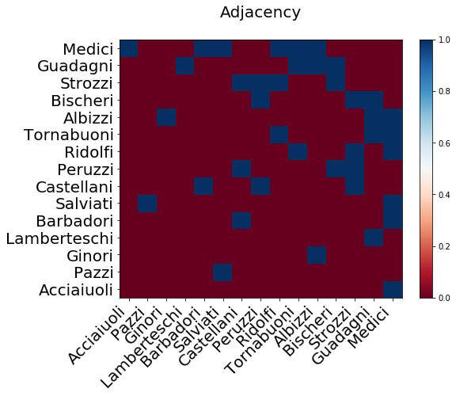

```python
adj_labeled = nx.to_pandas_adjacency(florentine)
order = adj_labeled.sum().sort_values().index
adj_labeled = adj_labeled.loc[order,order]
plt.figure(figsize = (8,6))
plt.pcolor(adj_labeled,cmap=plt.cm.RdBu)
plt.yticks(np.arange(0.5, len(adj_labeled.index), 1), adj_labeled.index, fontsize = 20)
plt.xticks(np.arange(0.5, len(adj_labeled.index), 1), adj_labeled.columns, rotation =45, ha='right', fontsize=20 )
plt.title('Adjacency\n',fontsize=20)
cbar =plt.colorbar()
```

# Graph Plotting Algorithms

- Can learn something by placing the nodes in an intelligent way
- Spring Algorithm: Put nodes that are connected closer together

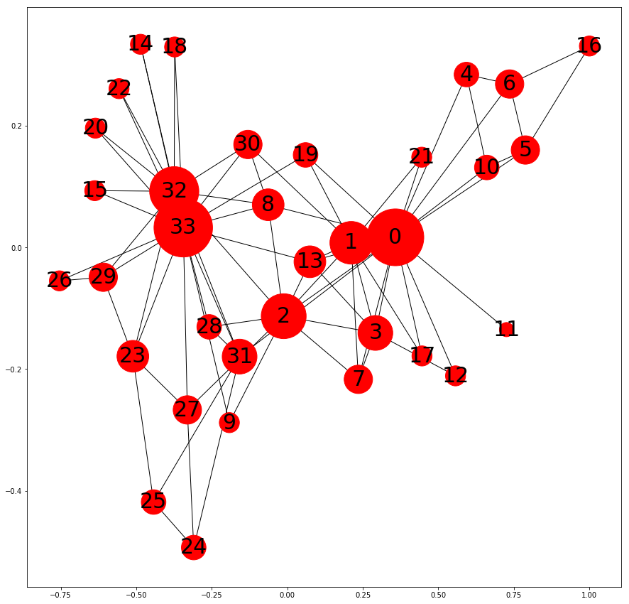

```python
plt.figure(figsize=(15,15))
pos = nx.spring_layout(karate)
deg = nx.degree(karate)
deg = [deg[k]*400 for k in karate.nodes]
nx.draw_networkx(karate,pos=pos, with_labels=True,
                node_size=deg,font_size=30)
```

# Add Color

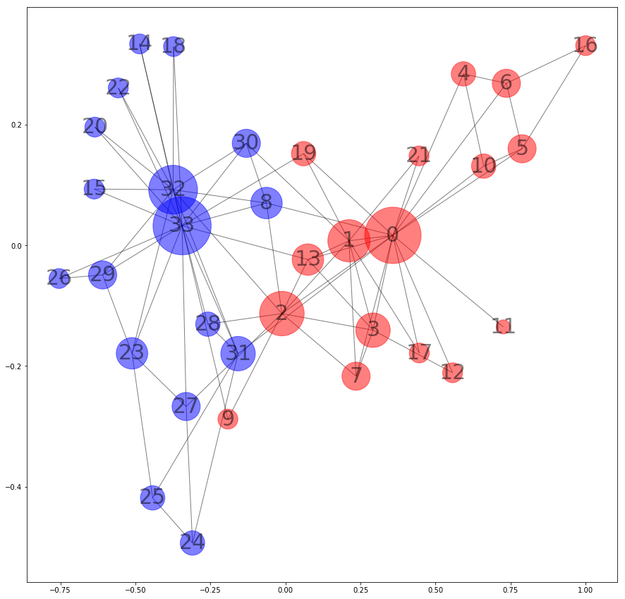

```python
plt.figure(figsize=(15,15))
colors = []
for n in karate.nodes:
    if n in greedy_2[0]:
        colors.append('blue')
    else:
        colors.append('red')
nx.draw_networkx(karate,pos=pos, with_labels=True,
                node_size=deg,font_size=30, node_color = colors,alpha=.5)
```

# Add Membership

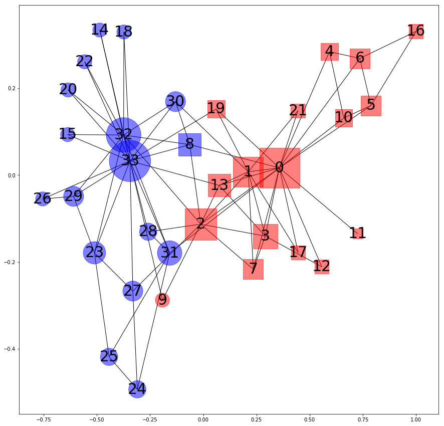

```python
plt.figure(figsize=(15,15))
m1 = [n for n in karate.nodes if n in membership[0]]
m1_col = [colors[i] for i, n in enumerate(karate.nodes) if n in membership[0]]
m1_deg = [deg[i] for i, n in enumerate(karate.nodes) if n in membership[0]]
m2 = [n for n in karate.nodes if n in membership[1]]
m2_col = [colors[i] for i, n in enumerate(karate.nodes) if n in membership[1]]
m2_deg = [deg[i] for i, n in enumerate(karate.nodes) if n in membership[1]]
nx.draw_networkx_nodes(nx.subgraph(karate,m1),pos=pos, alpha=.5,
                node_size=m1_deg, node_color = m1_col, node_shape='s',)
nx.draw_networkx_nodes(nx.subgraph(karate,m2),pos=pos,alpha=.5,
                node_size=m2_deg, node_color = m2_col,)
nx.draw_networkx_labels(karate, pos=pos,font_size=30,)
nx.draw_networkx_edges(karate,pos=pos,with_labels=True)
```

# Is the Relationship Significant?

## P(join club | friend joins)

- TNAM and Statnet in R
- Bayesian modeling with pymc3, stan, or Edward
- Spatial model for simple models
  - Fewer canned models in Python. We have to add an uninformative exogenous variable

  ## NO OLS, your observations are not independent

```python
from pysal.weights.weights import W as inst_weights
y = []
x = []
f = 0
for n in karate.nodes:
#     x.append()
    if f:
        x.append([1,0])
        f=0
    else:
        x.append([0,1])
        f =1
    if n in membership[0]:
        y.append(0)
    else: y.append(1)
x = np.array(x)
y = np.array([y]).T
neighbors = {n: list(karate[n].keys()) for n in karate.nodes}
neighbors = inst_weights(neighbors)
neighbors.transform='r'
m = ps.spreg.GM_Lag(y,x,w=neighbors, spat_diag=True,)
print(m.summary)
```

```
REGRESSION
----------
SUMMARY OF OUTPUT: SPATIAL TWO STAGE LEAST SQUARES
--------------------------------------------------
Data set            :     unknown
Weights matrix      :     unknown
Dependent Variable  :     dep_var                Number of Observations:          34
Mean dependent var  :      0.5000                Number of Variables   :           4
S.D. dependent var  :      0.5075                Degrees of Freedom    :          30
Pseudo R-squared    :      0.7232
Spatial Pseudo R-squared: omitted due to rho outside the boundary (-1, 1).
------------------------------------------------------------------------------------
            Variable     Coefficient       Std.Error     z-Statistic     Probability
------------------------------------------------------------------------------------
            CONSTANT      -0.2500000             nan             nan             nan
               var_1       0.2500000       0.0320442       7.8017275       0.0000000
               var_2      -0.1250000             nan             nan             nan
           W_dep_var       1.0395490       0.2449925       4.2431877       0.0000220
------------------------------------------------------------------------------------
Instrumented: W_dep_var
Instruments: W_var_1, W_var_2
Warning: *** WARNING: Estimate for spatial lag coefficient is outside the boundary (-1, 1). ***

DIAGNOSTICS FOR SPATIAL DEPENDENCE
TEST                           MI/DF       VALUE           PROB
Anselin-Kelejian Test             1           2.192          0.1387
================================ END OF REPORT =====================================
```

# Hypothesize About Network Construction

- Karate Network: Network represents friendships
- Hypothesis Friends of friends are more likely to become friends
- Expectation: See more triangles than random

```python
n = len(karate.nodes)
den = nx.density(karate)
t = nx.triangles(karate)
t = sum([t[i] for i in t])
triangles = []
for sim in range(500):
    g = nx.gnp_random_graph(n,den)
    tri = nx.triangles(g)
    triangles.append(sum(tri[i] for i in tri))
(t-np.mean(triangles))/np.std(triangles)
```

```
5.0299246184738093
```

# Other metrics to compare

- Degree distribution
- Centrality distribution
- Centralization

# Centrality Distributions

- Random graph above assumes every pair has the same probability of having an edge.
- Each node therefore has on average the same number of ties (expected degree)
- Many real networks follow a power law
  - More nodes than expected have many ties or few ties
  - Distribution of degree has fat tails
- Are there super popular hubs? Are there lots of loners or individuals with only one tie?

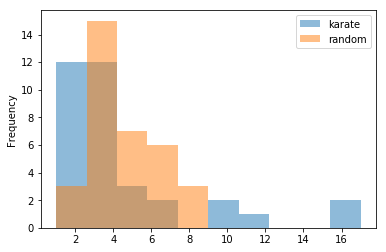

```python
deg = [i[1] for i in nx.degree(karate)]
g_deg = [i[1] for i in nx.degree(g)]
pd.DataFrame({'karate':deg,'random':g_deg}).plot.hist(alpha = .5)
```

# Florentine Network

- What do you expect the degree distribution to look like?
- Why?
- Calculate it and see

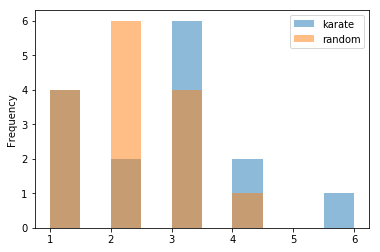

```python
deg = [i[1] for i in nx.degree(florentine)]
g = nx.gnp_random_graph(len(florentine.nodes),nx.density(florentine))
g_deg = [i[1] for i in nx.degree(g)]
pd.DataFrame({'karate':deg,'random':g_deg}).plot.hist(alpha = .5)
```

# Degree Distribution and Network Structure

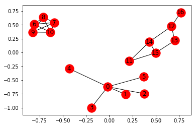

```python
g = nx.Graph()
g.add_nodes_from(list(range(16)))
g.add_edges_from([(0,1),(0,2),(0,3),(0,4),(0,5),
                 (6,7),(6,8),(6,9),(6,10),(7,8),(7,9),(7,10),(8,9),(8,10),(9,10),
                 (11,14),(11,15),(12,13),(12,16),(13,15),(14,15),(14,12)])
pos = nx.spring_layout(g,k=.65)
nx.draw_networkx(g,pos=pos)
```

# Centralization

- How central the most central node is in relation to all others
- Centralized graphs have one or a few highly prominent nodes
- Decentralized graphs have more equal distribution of influence
- Strong implications for behavior and information flow

### Sum of difference between highest centrality node and all others, divided by the max difference for network of the same size

```python
def centralization(g):
    deg = [i[1] for i in nx.degree(g)]
    max_deg = max(deg)
    N = len(g.nodes)-1
    numerator = sum([max_deg -i for i in deg])
    denomenator = (N-1)**2
    return numerator/denomenator
```

# Centralization

- Extent to which graph has some nodes that are much more prominent than others
- Centralized graphs have one or a few highly prominent nodes
- Decentralized graphs have more equal distribution of influence
- Strong implications for behavior and information flow

```
1.25
0.0
0.25
```

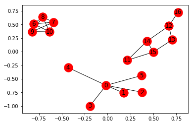

```python
print(centralization(nx.subgraph(g,list(range(6)))))
print(centralization(nx.subgraph(g,list(range(6,11)))))
print(centralization(nx.subgraph(g,list(range(11,17)))))
nx.draw_networkx(g,pos=pos)
```

# Proper Baselines: Random Networks Capturing These Dynamics

```
0.3136094674556213
```

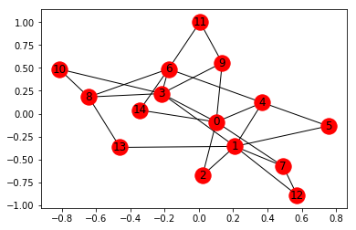

```python
g=nx.barabasi_albert_graph(len(florentine.nodes),2)
nx.draw_networkx(g)
print(centralization(g))
```

# Compare the preferential attachment graph to others

- Barabasi Albert graph degree distribution to Karate and Erdos Renyi
- Compare centralization to Karate and Erdos Renyi

```
ER centralization:  0.171875
Karate centralization:  0.412109375
```

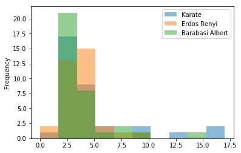

```python
g=nx.barabasi_albert_graph(len(karate.nodes),2)
g_rand = nx.erdos_renyi_graph(len(karate.nodes),nx.density(g))
print('ER centralization: ',centralization(g_rand))
print('Karate centralization: ',centralization(karate))
pd.DataFrame({'Karate': [i[1] for i in nx.degree(karate)],
             'Erdos Renyi': [i[1] for i in nx.degree(g_rand)],
             'Barabasi Albert': [i[1] for i in nx.degree(g)]}
            ).plot.hist(alpha=.5)
```

# Hypothesis Testing: Preferential Attachment

### Use ERGM in R, with Statnet

- Probability of observed network given covariates about the network
- Used to generate random graphs with specific models
- Only works for small networks, hard to estimate
- Latent Space Models also useful

# Congratulations!

[figure not shown]

# The rest of the notebook contains a case study for you to go through on your own

# Case Study: Senate Co-Sponsorship

- Nodes: Senators
- Links: Sponsorship of the same piece of legislation.
- Weighted

#### Download here:

  https://dataverse.harvard.edu/file.xhtml;jsessionid=e627083a7d8f43616bbe7d4ada3e?fileId=615937&version=RELEASED&version=.0

#### Start with the cosponsors.txt file

- Similar to an edgelist for a bipartite graph
  - Each line is a bill
  - Each line lists all cosponsors

# Load The Cosponsor Data

1. Instantiate a list for the edgelist
2. Open the file
3. Loop through lines
4. Store the lines

```python
edges = []
with open('Cosponsors.txt') as d:
    for line in d:
        edges.append(line.split())
```

# Subset the Data: Year

### 2000

- Download dates.txt
- Each row is the date
- Year, month, day separated by "-"

```python
dates = pd.read_csv('Dates.txt',sep='-',header=None)
dates.columns = ['year','month','day']
index_loc = np.where(dates.year==2000)
edges_00 = [edges[i] for i in index_loc[0]]
```

# Subset the Data: Senate

- Download senate.csv
- Gives the ids for senators
- Filter down to the rows for 106th congress (2000)

### This gives us our nodes

- Instantiate adjacency matrix of size nxn
- Create an ordinal index so we can index the matrix
- Add an attribute

```python
# Get nodes
senate = pd.read_csv('Senate.tab',sep='\t')
senators = senate.loc[senate.congress==106,['id','party']]
# Creae adjacency matrix
adj_mat = np.zeros([len(senators),len(senators)])
senators = pd.DataFrame(senators)
senators['adj_ind']=range(len(senators))
# Create Graph Object
senateG= nx.Graph()
senateG.add_nodes_from(senators.id)
party_dict = dict(zip(senators.id,senators.party))
nx.set_node_attributes(senateG, name='party',values=party_dict)
```

# Create the network (two ways)

```python
for bill in edges_00:
    if bill[0] == "NA": continue
    bill = [int(i) for i in bill]
    if bill[0] not in list(senators.id): continue
    combos = list(itertools.combinations(bill,2))
    senateG.add_edges_from(combos)
    for pair in combos:
        i = senators.loc[senators.id == int(pair[0]), 'adj_ind']
        j = senators.loc[senators.id == int(pair[1]), 'adj_ind']
        adj_mat[i,j]+=1
        adj_mat[j,i]+=1
```

# Set edge weights for Network Object

```python
for row in range(len(adj_mat)):
    cols = np.where(adj_mat[row,:])[0]
    i = senators.loc[senators.adj_ind==row,'id']
    i = int(i)
    for col in cols:
        j = senators.loc[senators.adj_ind==col,'id']
        j = int(j)
        senateG[i][j]['bills']=adj_mat[row,col]
```

# Thresholding

- Some bills have everyone as a sponsor
- These popular bills are less informative, end up with complete network
- Threshold: Take edges above a certain weight (more than n cosponsorships)
- Try different numbers

```python
bill_dict = nx.get_edge_attributes(senateG,'bills')
elarge=[(i,j) for (i,j) in bill_dict  if bill_dict[(i,j)] >25]
```

# Look at the network

- Different layouts possible:  
  https://networkx.github.io/documentation/networkx-1.10/reference/drawing.html

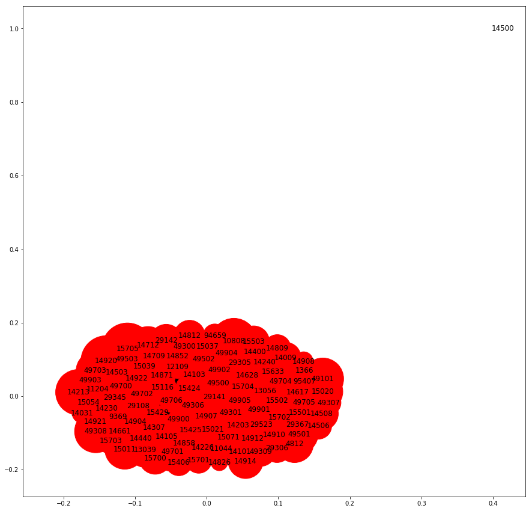

```python
plt.figure(figsize=(15,15))
pos = nx.spring_layout(senateG,k=.6)
deg = [(i[1]**2)/2700 for i in nx.degree(senateG, weight='bills')]
nx.draw_networkx(senateG, pos=pos, edgelist = elarge,
                 node_size = deg, with_labels=True)
```

# Take out the singletons to get a clearer picture:

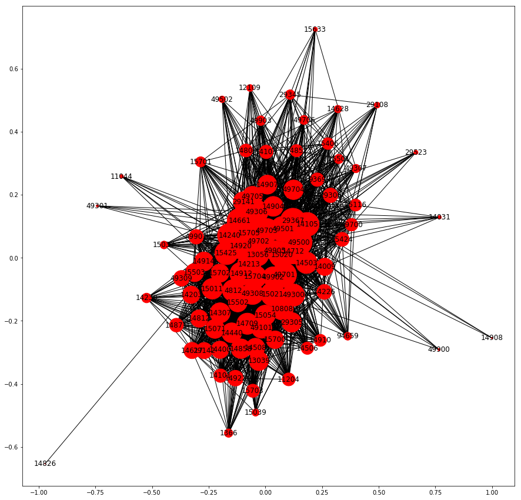

```python
plt.figure(figsize=(15,15))
senateGt= nx.Graph()
senateGt.add_nodes_from(senateG.nodes)
senateGt.add_edges_from(elarge)
deg = senateGt.degree()
rem = [n[0] for n in deg if n[1]==0]
senateGt_all = senateGt.copy()
senateGt.remove_nodes_from(rem)
deg = [(i[1])**1.7 for i in nx.degree(senateGt, weight='bills')]
pos = nx.spring_layout(senateGt,k=.7)
nx.draw_networkx(senateGt,pos=pos,node_size =deg, with_labels=True)
```

# Look at the degree distribution

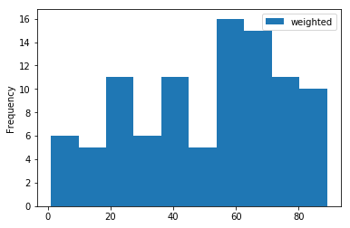

```python
pd.DataFrame({'weighted':[(i[1]) for i in nx.degree(senateGt, weight='bills')],
                          }).plot.hist()
```

# Look at party in the network

### Extract the party information

- Democrats coded as 100, republicans as 200

```python
party = nx.get_node_attributes(senateG,'party')
dems = []
gop = []
for i in party:
    if party[i]==100: dems.append(i)
    else: gop.append(i)
```

## Prepare the Visualization

- Create positional coordinates for the groups with ties, and without ties
- Instantiate dictionaries to hold different sets of coordinates
- Loop through party members
  - If they have no parters, add calculated position to the lonely dictionary
  - If they have partners, add calculated position to the party dictionary

```python
pos = nx.spring_layout(senateGt,k=.65)
pos_all = nx.circular_layout(senateG)
dem_dict={}
gop_dict={}
dem_lone = {}
gop_lone= {}
for n in dems:
    if n in rem: dem_lone[n]=pos_all[n]
    else:dem_dict[n] = pos[n]
for n in gop:
    if n in rem: gop_lone[n]=pos_all[n]
    else:gop_dict[n] = pos[n]
```

## Visualize the network by party

- Create lists of the party members who have ties
- Draw nodes in four categories using the position dictionaries we created
  - party members, untied party members

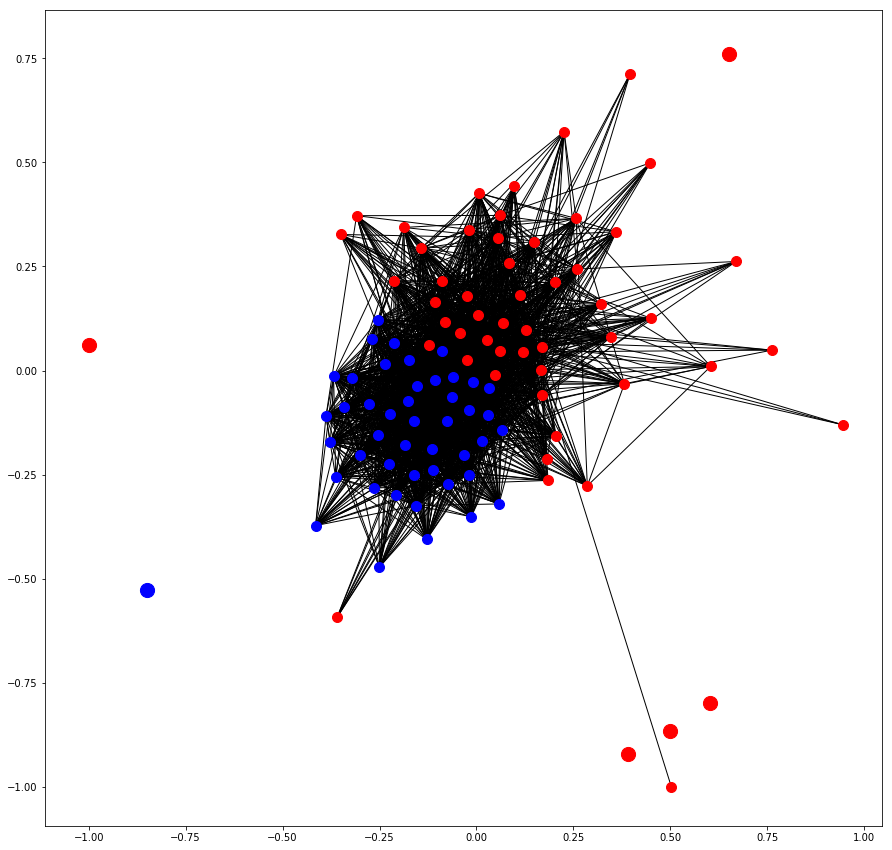

```python
plt.figure(figsize=(15,15))
dems = list(set(dems)-set(rem))
gop = list(set(gop)-set(rem))
nx.draw_networkx_nodes(senateGt, pos=dem_dict, nodelist = dems,node_color='b',node_size = 100)
nx.draw_networkx_nodes(senateGt, pos=gop_dict, nodelist = gop,node_color='r', node_size = 100)
nx.draw_networkx_nodes(senateG, pos=dem_lone, nodelist = list(dem_lone.keys()),node_color='b',node_size = 200)
nx.draw_networkx_nodes(senateG, pos=gop_lone, nodelist = list(gop_lone.keys()),node_color='r', node_size = 200)
nx.draw_networkx_edges(senateGt,pos=pos, edgelist=elarge)
```

# Do it again with a higher threshold:

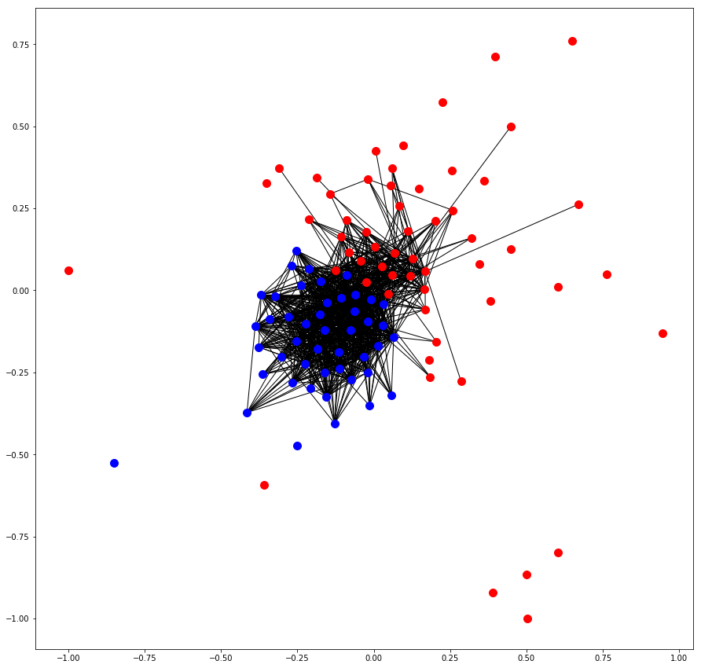

```python
elarge=[(i,j) for (i,j) in bill_dict  if bill_dict[(i,j)] >35]
plt.figure(figsize=(15,15))
dems = list(set(dems)-set(rem))
gop = list(set(gop)-set(rem))
nx.draw_networkx_nodes(senateGt, pos=dem_dict, nodelist = dems,node_color='b',node_size = 100)
nx.draw_networkx_nodes(senateGt, pos=gop_dict, nodelist = gop,node_color='r', node_size = 100)
nx.draw_networkx_nodes(senateGt_all, pos=dem_lone, nodelist = list(dem_lone.keys()),node_color='b',node_size = 100)
nx.draw_networkx_nodes(senateGt_all, pos=gop_lone, nodelist = list(gop_lone.keys()),node_color='r', node_size = 100)
nx.draw_networkx_edges(senateGt,pos=pos, edgelist=elarge)
```

# Hypothesis: Homophily

- Excpect senators who have more similar beliefs (in same party) to co-sponsor bills more often
- Use the greedy algorithm to generate communities

```python
colors = modular_communities(senateGt, weight = 'bills')
```

# Visualize the Communities

- Calculate a position for all nodes
- Separate network by the communities
- Draw the first set as red
- Draw the second set as blue
- Add the edges

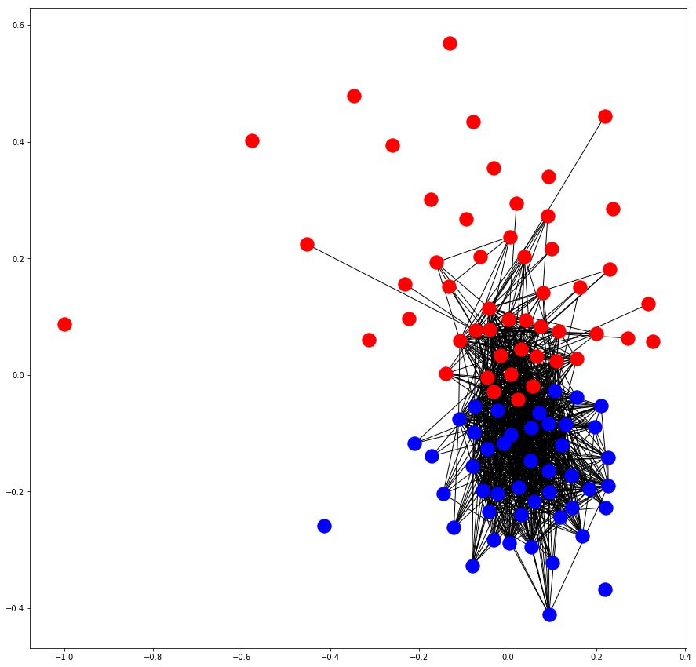

```python
elarge=[(i,j) for (i,j) in bill_dict  if bill_dict[(i,j)] >35]
plt.figure(figsize=(15,15))
pos = nx.spring_layout(senateGt)
pos0={}
pos1={}
for n in colors[0]:
    pos0[n] = pos[n]
for n in colors[1]:
    pos1[n] = pos[n]
nx.draw_networkx_nodes(senateGt, pos=pos0, nodelist = colors[0],node_color='r')
nx.draw_networkx_nodes(senateGt, pos=pos1, nodelist = colors[1],node_color='b')
nx.draw_networkx_edges(senateGt,pos=pos, edgelist=elarge)
```